# Milestone Report

Alex Wiebe

8/5/2020

# Capstone Milestone Report

## Executive Summary

```r
twit <- file("en_US.twitter.txt")
twit_lines <- readLines(twit)
blog <- file("en_US.blogs.txt")
blog_lines <- readLines(blog)
news <- file("en_US.news.txt")
news_lines <- readLines(news)

twit_words <- wordcount(twit_lines, sep = " ")
blog_words <- wordcount(blog_lines, sep = " ")
news_words <- wordcount(news_lines, sep = " ")
word_table <- cbind(twit_words, blog_words, news_words)
saveRDS(word_table, "/Users/ajwiebe/Capstone Project/final/en_US/word_table.rds")
```

```r
word_table <- readRDS("/Users/ajwiebe/Capstone Project/final/en_US/word_table.rds")
print(word_table)
```

```
##      twit_words blog_words news_words
## [1,]   30373543   37334131   34372530
```

```r
summary(length(twit_lines))
summary(length(blog_lines))
summary(length(news_lines))
summary_table <- rbind(summary(length(blog_lines)), summary(length(twit_lines)), summary(length(news_lines)))
saveRDS(summary_table, "/Users/ajwiebe/Capstone Project/final/en_US/summary_table.rds")
```

```r
summary_table <- readRDS("/Users/ajwiebe/Capstone PRoject/final/en_US/summary_table.rds")
print(summary_table)
```

```
##         Min. 1st Qu.  Median    Mean 3rd Qu.    Max.
## [1,]  899288  899288  899288  899288  899288  899288
## [2,] 2360148 2360148 2360148 2360148 2360148 2360148
## [3,] 1010242 1010242 1010242 1010242 1010242 1010242
```

The lines of text from each dataset were then converted into a data frame and subsetted accordingly. Ten percent of each type of data was used. The subsetted data was then unified in order to have a complete repository of the training data. The repository was cleaned in order to include the source of each line of text (Twitter, a blog, or the news).

```r
##The total data frame
data.frame(type = c("twitter", "blog", "news"), words = c(length(twit_words), length(blog_words), length(news_words)))

twit_df <- data.frame(text = twit_lines)
blogs_df <- data.frame(text = blog_lines)
news_df <- data.frame(text = news_lines)

##Subsets from twitter
set.seed(25)
twit_train2 <- twit_df %>% sample_n(., nrow(twit_df)*0.1)
##Subset from blogs
blog_train2 <- blogs_df %>% sample_n(., nrow(blogs_df)*0.1)
##Subset from news
news_train2 <- news_df %>% sample_n(., nrow(news_df)*0.1)

##Make the repository
repo_samp <- bind_rows(mutate(twit_train2, source = "twit_df"), mutate(blog_train2, source = "blogs_df"), mutate(news_train2, source = "news_df"))
repo_samp$source <- as.factor(repo_samp$source)
```

```r
swear_words <- tibble(line = 1:13, text = swears)
tidy_swears <- swear_words %>% unnest_tokens(word, text)

replace_reg <- "[^[:alpha:][:space:]]*"
replace_url <- "http[^[:space:]]*"
replace_aaa <- "\\b(?=\\w*(\\w)\\1)\\w+\\b"

##Clean the repo
clean_samp <- repo_samp %>% mutate(text = str_replace_all(text, replace_reg, "")) %>%
  mutate(text = str_replace_all(text, replace_url, "")) %>%
  mutate(text = str_replace_all(text, replace_aaa, "")) %>%
  mutate(text = iconv(text, "ASCII//TRANSLIT"))
```

The words were tokenized in a clean repository with no stop words.

```r
clean_samp <- readRDS("/Users/ajwiebe/Capstone Project/final/en_US/clean_samp.rds")
head(clean_samp)
```

```
##                                                                                                          text
## 1  Please back online poker  Downs horse race wagering sites show sites can be regulated  age verified Thanks
## 2                                                                        RT  A Regular  workshop sounds great
## 3                                                                                      What up bruh lets work
## 4       Made it home  house  ok no gas leaks    is  mounted Corcoran Library shelves are up  saw one  on the
## 5  Proud of my boy for  the Buckeyes together Your true character as a leader shows up when adversity sets in
## 6                    I think your digital potluck should combine tasty dishes together in the spirit a mashup
##    source
## 1 twit_df
## 2 twit_df
## 3 twit_df
## 4 twit_df
## 5 twit_df
## 6 twit_df
```

```r
tidy_repo <- readRDS("/Users/ajwiebe/Capstone Project/final/en_US/tidy_repo.rds")
head(tidy_repo)
```

```
##      source     word
## 1.2 twit_df   online
## 1.3 twit_df    poker
## 1.5 twit_df    horse
## 1.6 twit_df     race
## 1.7 twit_df wagering
## 1.8 twit_df    sites
```

## Exploratory Data Analysis

The tidy repository was organized into an object that contains each tokenized word that covers up to ninty percent of the data, the frequency of each word's appearance, its coverage, and proportion compared to the rest of the data.

```r
cover_90 <- tidy_repo %>%
  count(word) %>%
  mutate(proportion = n / sum(n)) %>%
  arrange(desc(proportion)) %>%
  mutate(coverage = cumsum(proportion)) %>%
  filter(coverage <= 0.9)
```

```r
cover_90 <- readRDS("/Users/ajwiebe/Capstone Project/final/en_US/cover_90.rds")
head(cover_90)
```

```
##     word     n  proportion    coverage
## 1     im 23982 0.007022437 0.007022437
## 2   time 21074 0.006170913 0.013193349
## 3   dont 17448 0.005109143 0.018302492
## 4    day 16921 0.004954826 0.023257319
## 5   love 16115 0.004718813 0.027976132
## 6 people 15782 0.004621303 0.032597435
```

Some preliminary plots were made to illustrate the findings in the data.

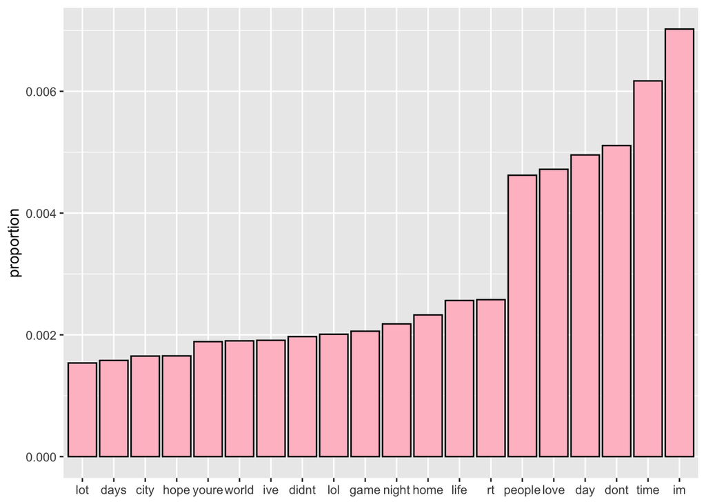

```r
library(ggplot2)
library(dplyr)
cover_90 %>%
  top_n(20, proportion) %>%
  mutate(word = reorder(word, proportion)) %>%
  ggplot(aes(word, proportion)) +
  geom_col() +
  xlab(NULL) + geom_bar(fill = "pink", color = "black", stat = "identity")
```

It was necessary to remove all stop words because otherwise, the plot would have almost entirely been stop words.

## Application Plan

This application is going to use a function as a model to predict the following word, when passed a single word or a string of words. It will use five clean sets of data containing ngrams to predict words. For example, if passed three words, it should predict the fourth word based on a set of quadgrams from the training data. The application will also display various statistics about the data. It should be compact enough to use on a range of devices and relatively accurate in terms of words prediction.